# Text Processing

Matt Cliff

May 10, 2018

## Demo

This is going to be a demonstration to pull blocks of texts (political speeches) from various parties, then given a new block of text to identify if which poltical party it most associates with.

(Idea from a presentation given by Carlos Bossy who did this with state of the union addresses from two presidents.)

### References

Great [feature comparision](https://docs.quanteda.io/articles/pkgdown/comparison.html) from quanteda.

[Online Analysis](http://stateoftheunion.onetwothree.net/)

Possible places to soure * [R sotu package](https://github.com/statsmaths/sotu) * [https://en.wikisource.org/wiki/Portal:State_of_the_Union_Speeches_by_United_States_Presidents] * [Data as Journalism](https://onlinejournalismblog.com/2018/02/05/text-as-data-journalism-sotu-speeches/) * [Kaggle](https://www.kaggle.com/rtatman/state-of-the-union-corpus-1989-2017) * [Kaggle Tokenization Tutorial](https://www.kaggle.com/rtatman/tokenization-tutorial/code)

### Data

Using the *sotu* package the **sotu_meta** dataset is a dataframe with meta data of the 236 speeches, and sotu_text is a character vector with one address per element

```r
str(sotu_meta)
```

```
## Classes 'tbl_df', 'tbl' and 'data.frame':    236 obs. of  5 variables:
##  $ president   : chr  "George Washington" "George Washington" "George Washington" "George Washington" ...
##  $ year        : int  1790 1790 1791 1792 1793 1794 1795 1796 1797 1798 ...
##  $ years_active: chr  "1789-1793" "1789-1793" "1789-1793" "1789-1793" ...
##  $ party       : chr  "Nonpartisan" "Nonpartisan" "Nonpartisan" "Nonpartisan" ...
##  $ sotu_type   : chr  "speech" "speech" "speech" "speech" ...
```

```r
head(sotu_meta$year)
```

```
## [1] 1790 1790 1791 1792 1793 1794
```

```r
head(unlist(lapply(sotu_text, nchar)))
```

```
## [1]  6712  8395 14143 12703 11637 17591
```

```r
df <- data.frame(x=sotu_meta$year, y=unlist(lapply(sotu_text, nchar)))
head(df)
```

```
##      x     y
## 1 1790  6712
## 2 1790  8395
## 3 1791 14143
## 4 1792 12703
## 5 1793 11637
## 6 1794 17591
```

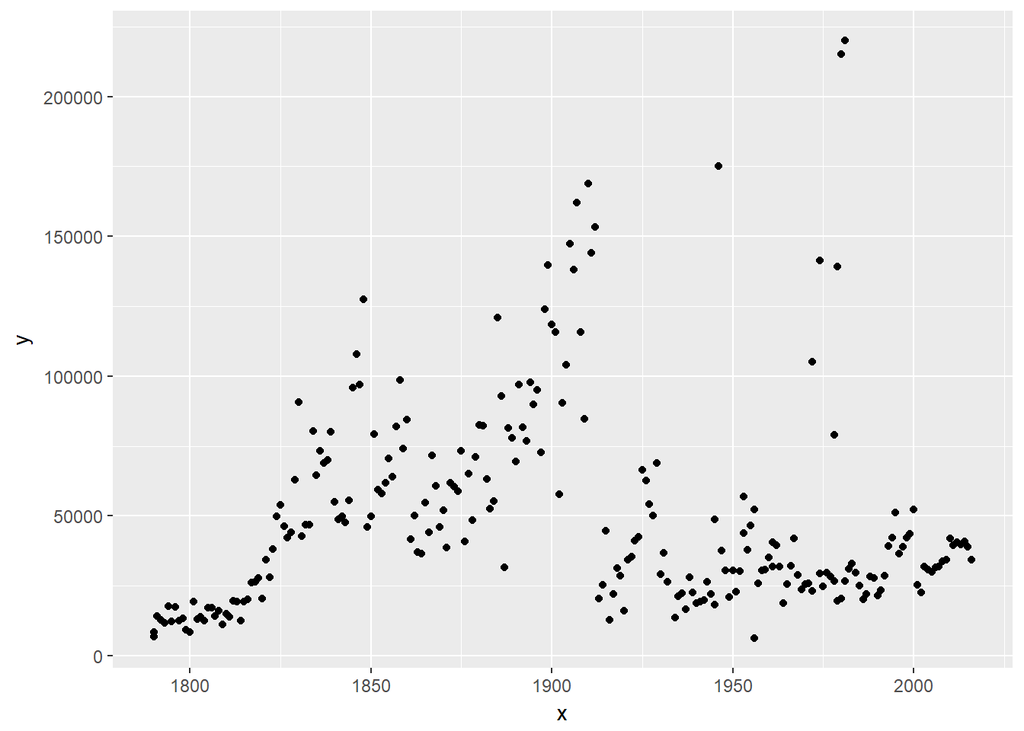

```r
ggplot(data=df, aes(x, y)) + geom_point()
```

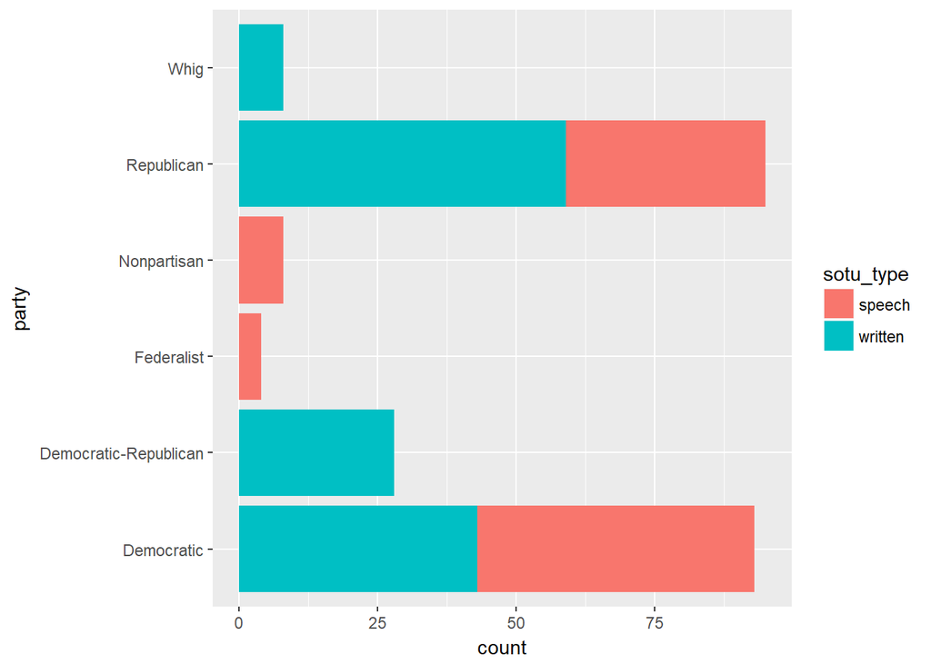

```r
ggplot(sotu_meta, aes(x=party, fill=sotu_type)) +
    geom_bar() +
    coord_flip()
```

best case, some nested folder structure based on political party what kind of meta data about the text

Let’s call on tidy text next

```r
#df <- mutate(sotu_meta, text=sotu_text)
str(sotu_text[236])
```

```
##  chr "Thank you. Mr. Speaker, Mr. Vice President, Members of Congress, my fellow Americans: Tonight marks the eighth "| __truncated__
```

```r
sotu_meta[236,]
```

```
## # A tibble: 1 x 5
##   president     year years_active party      sotu_type
##   <chr>        <int> <chr>        <chr>      <chr>
## 1 Barack Obama  2016 2013-2016    Democratic speech
```

```r
tokens <- data.frame(text=sotu_text[236], stringsAsFactors=FALSE) %>% unnest_tokens(word, text)


str(tokens)
```

```
## 'data.frame':    6078 obs. of  1 variable:
##  $ word: chr  "thank" "you" "mr" "speaker" ...
```

```r
head(tokens)
```

```
##        word
## 1     thank
## 1.1     you
## 1.2      mr
## 1.3 speaker
## 1.4      mr
## 1.5    vice
```

```r
head(tokens %>% inner_join(get_sentiments("bing")))
```

```
##           word sentiment
## 1        thank  positive
## 2         vice  negative
## 3   appreciate  positive
## 4 constructive  positive
## 5         work  positive
## 6         like  positive
```

```r
getsentiment <- function(textdata, lexicon="bing") {
    #print(class(data))
    #print(str(data))
    sentiment <- data.frame(text=textdata, stringsAsFactors = FALSE) %>%
        unnest_tokens(word, text) %>%
        inner_join(get_sentiments(lexicon), by="word") %>%
        dplyr::count(sentiment) %>%  # count the number of positive and negatives
        spread(sentiment, n, fill=0)  %>%  # made data wider rather than narrow
        mutate(sentiment = positive - negative)


    return(sentiment)
}


#    %>%
#        mutate(president = data$president) %>%
#        mutate(sotu_type = data$sotu_type) %>%





sentiments <- ldply(lapply(sotu_text, getsentiment), data.frame)

head(df)
```

```
##      x     y
## 1 1790  6712
## 2 1790  8395
## 3 1791 14143
## 4 1792 12703
## 5 1793 11637
## 6 1794 17591
```

```r
head(cbind(sotu_meta, df))
```

```
##           president year years_active       party sotu_type    x     y
## 1 George Washington 1790    1789-1793 Nonpartisan    speech 1790  6712
## 2 George Washington 1790    1789-1793 Nonpartisan    speech 1790  8395
## 3 George Washington 1791    1789-1793 Nonpartisan    speech 1791 14143
## 4 George Washington 1792    1789-1793 Nonpartisan    speech 1792 12703
## 5 George Washington 1793    1793-1797 Nonpartisan    speech 1793 11637
## 6 George Washington 1794    1793-1797 Nonpartisan    speech 1794 17591
```

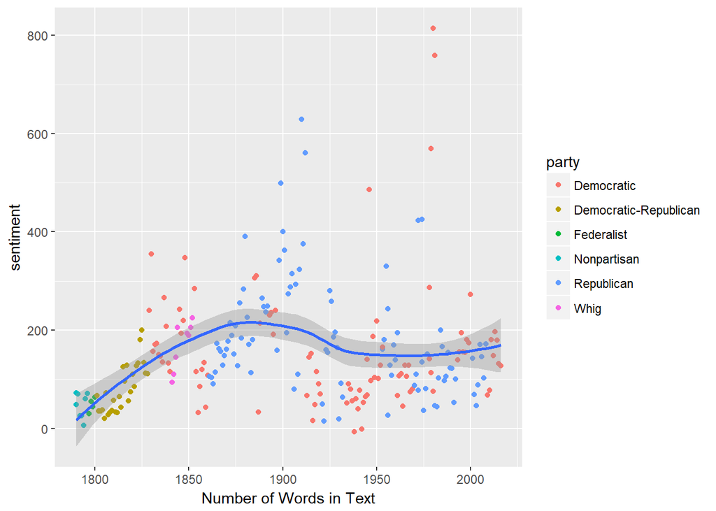

```r
df <- cbind(sotu_meta, sentiments) %>%
    mutate(len = unlist(lapply(sotu_text, nchar))) %>%
    mutate(wgt_sentiment = sentiment / len)

#sentiments <- getsentiment(df)


ggplot(df, aes(x = as.numeric(year), y = sentiment)) +
  geom_point(aes(color=party)) + # add points to our plot, color-coded by party
  geom_smooth(method = "auto") + # pick a method & fit a model
    xlab('Number of Words in Text')
```

```r
  #geom_point(aes(color = president)) + # add points to our plot,
```

Lets do a box plot by party

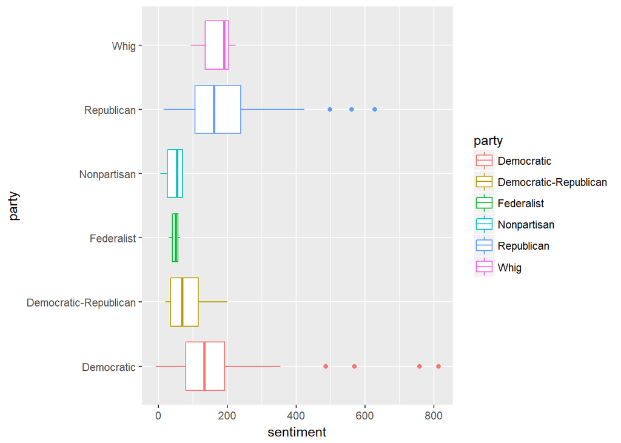

```r
ggplot(df, aes(x=party, y=sentiment, color=party)) +
    geom_boxplot() + coord_flip()
```

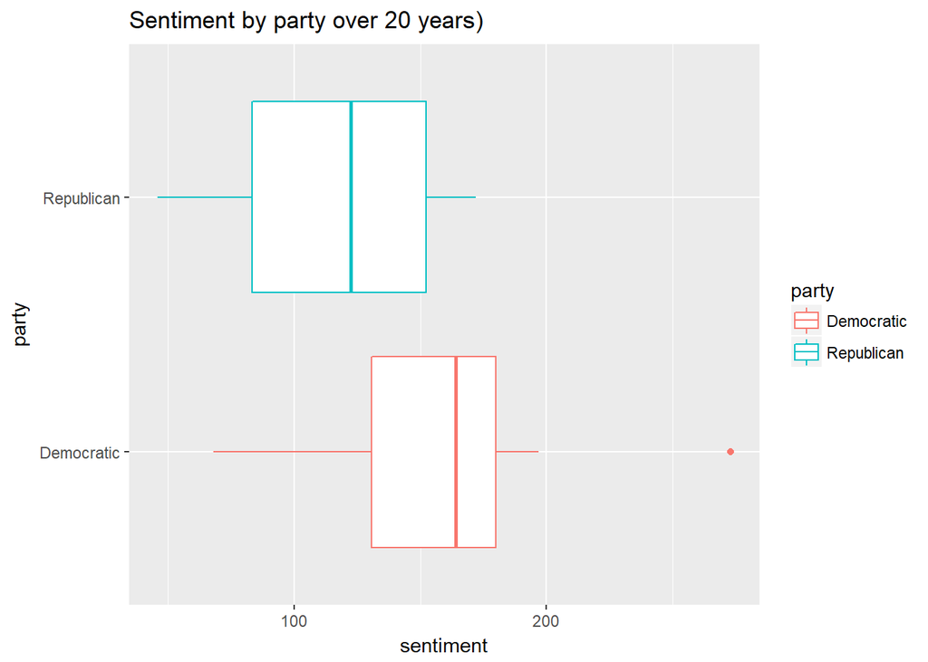

```r
# look at the last 20 years
ggplot(tail(df,20), aes(x=party, y=sentiment, color=party)) +
    geom_boxplot() + coord_flip() +
    labs(title="Sentiment by party over 20 years)")
```

But how long are they?

Try some weighted sentiments

[figure not shown]

```r
ggplot(tail(df,24), aes(x=len, fill=party)) +
     geom_density(alpha=0.5, aes(fill=factor(party))) +
    labs(title="Length Density by Party (past 60y)")
```

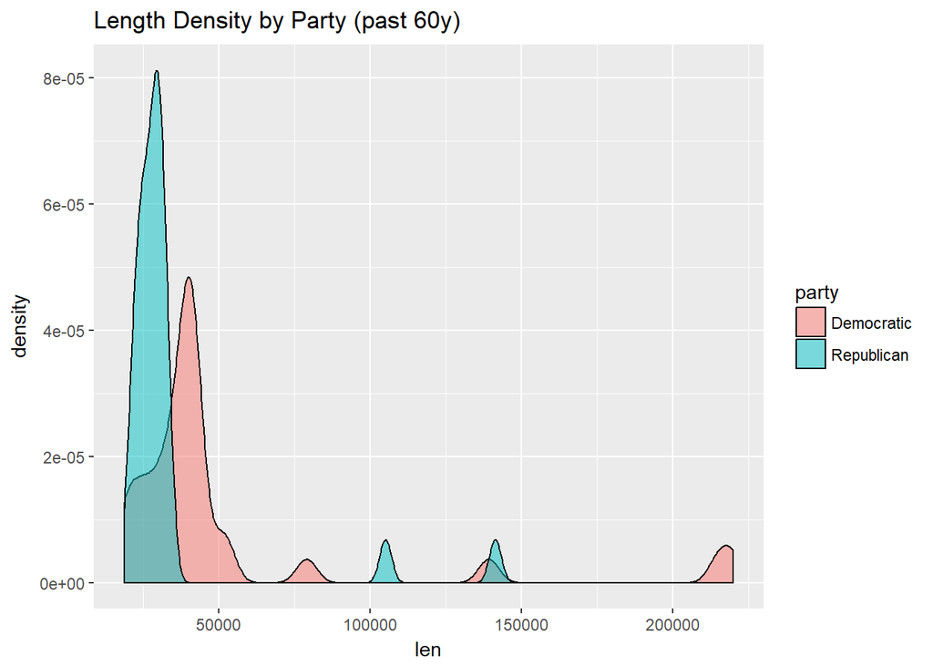

```r
ggplot(tail(df,60), aes(x=len, fill=party)) +
     geom_density(alpha=0.5, aes(fill=factor(party))) +
    labs(title="Length Density by Party (past 60y)")
```

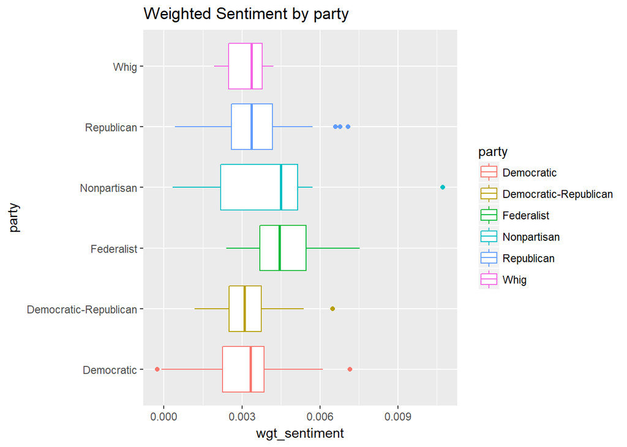

```r
ggplot(df, aes(x=party, y=wgt_sentiment, color=party)) +
    geom_boxplot() + coord_flip() +
    labs(title="Weighted Sentiment by party")
```

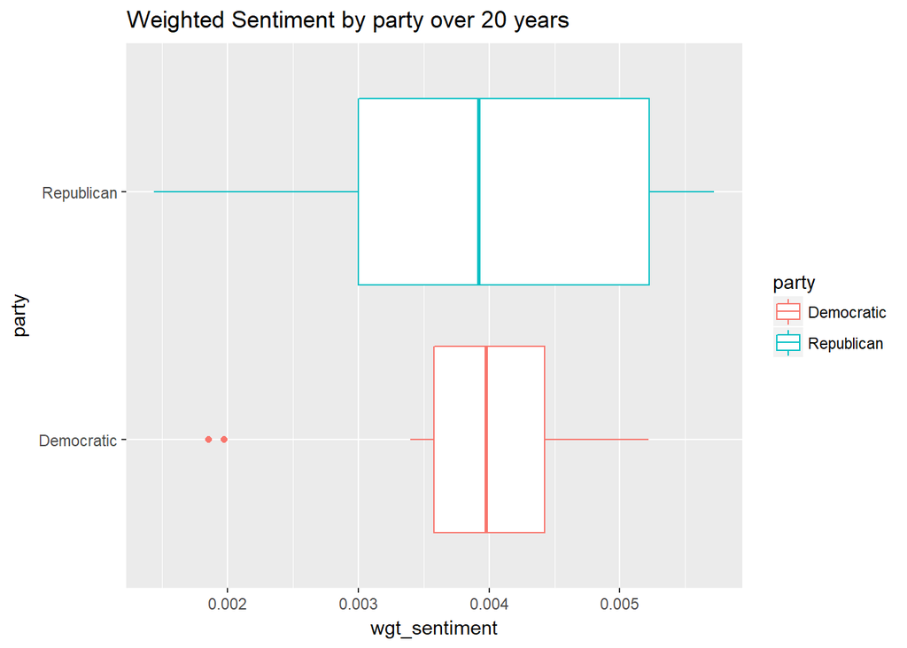

```r
# look at the last 20 years
ggplot(tail(df,20), aes(x=party, y=wgt_sentiment, color=party)) +
    geom_boxplot() + coord_flip() +
    labs(title="Weighted Sentiment by party over 20 years")
```

Now let’s try with a different lexicon *afinn* instead of *bing*

```r
getsentimentAfinn <- function(textdata, lexicon="afinn") {
    sentimentAfinn <- data.frame(text=textdata, stringsAsFactors = FALSE) %>%
        unnest_tokens(word, text) %>%
        inner_join(get_sentiments(lexicon), by="word")

    return(sum(sentimentAfinn$score))
}

sentiments2 <- ldply(lapply(sotu_text, getsentimentAfinn), data.frame)
names(sentiments2) <- c('sentiment')
```

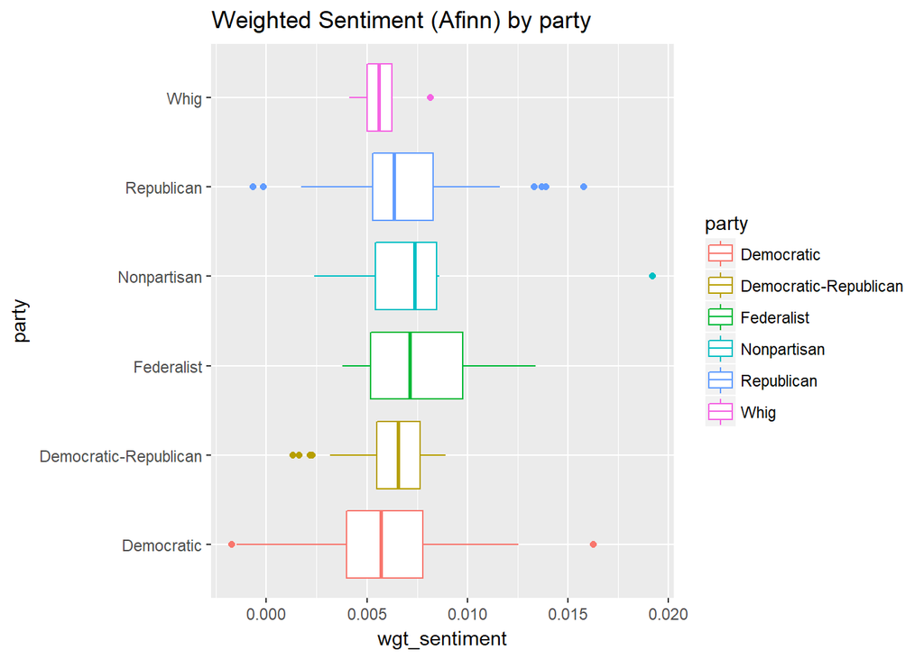

```r
df2 <- cbind(sotu_meta, sentiments2) %>%
    mutate(len = unlist(lapply(sotu_text, nchar))) %>%
    mutate(wgt_sentiment = sentiment / len)


ggplot(df2, aes(x=party, y=wgt_sentiment, color=party)) +
    geom_boxplot() + coord_flip() +
    labs(title="Weighted Sentiment (Afinn) by party")
```

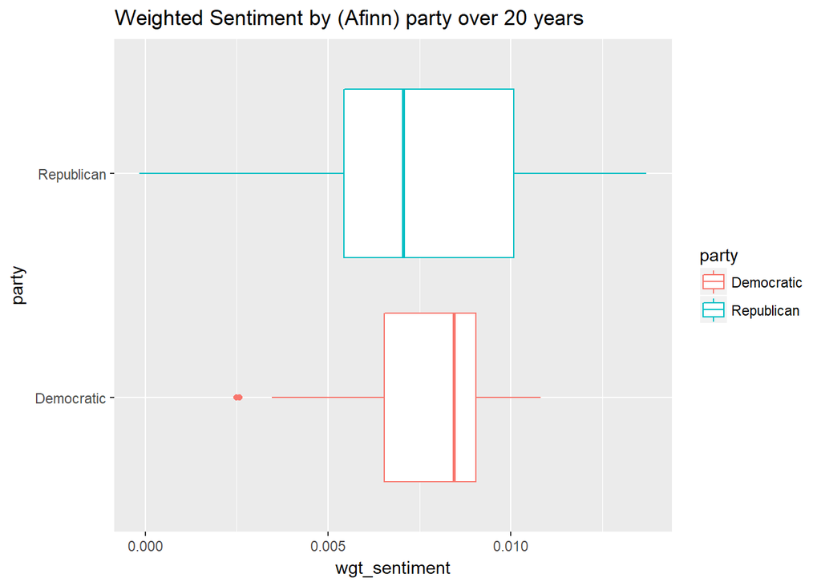

```r
# look at the last 20 years
ggplot(tail(df2,20), aes(x=party, y=wgt_sentiment, color=party)) +
    geom_boxplot() + coord_flip() +
    labs(title="Weighted Sentiment by (Afinn) party over 20 years")
```

### Model

List of packages ([comparision](https://docs.quanteda.io/articles/pkgdown/comparison.html))

- [Quanteda](https://docs.quanteda.io/reference/index.html)
- [tm]
- [tidytext]
- [corpus]
- [koRpus]

```r
tic("Generate DFM")
n <- 60 #236
samples <- sample(1:n, size=n*.8)

X_train <- tail(sotu_text, n)[samples]
y_train <- tail(sotu_meta,n)[samples,]
X_valid <- tail(sotu_text, n)[-samples]
y_valid <- tail(sotu_meta, n)[-samples,]

model_dfm <- dfm(X_train)
model_labels <- y_train$party
toc()
```

```
## Generate DFM: 0.36 sec elapsed
```

```r
# use Bernoulli Naive Bayes
model.nb <- textmodel_nb(model_dfm, model_labels)

# predict on one of them
tic("predict")
querydfm <- dfm(X_valid[1]) %>% dfm_select(pattern=model_dfm)
predict(model.nb, querydfm)
```

```
## $log.posterior.lik
##       Republican Democratic
## text1  -121731.7  -121749.9
##
## $posterior.prob
##       Republican   Democratic
## text1          1 1.312073e-08
##
## $nb.predicted
## [1] "Republican"
##
## $Pc
## Republican Democratic
##        0.5        0.5
##
## $classlabels
## [1] "Republican" "Democratic"
##
## $call
## predict.textmodel_nb(object = model.nb, newdata = querydfm)
```

```r
y_valid[1]
```

```
## # A tibble: 12 x 1
##    president
##    <chr>
##  1 Richard M. Nixon
##  2 Jimmy Carter
##  3 Jimmy Carter
##  4 Ronald Reagan
##  5 Ronald Reagan
##  6 George Bush
##  7 George Bush
##  8 William J. Clinton
##  9 George W. Bush
## 10 George W. Bush
## 11 Barack Obama
## 12 Barack Obama
```

```r
toc()
```

```
## predict: 0.44 sec elapsed
```

```r
# predict on one of them
tic("predict2")
querydfm <- dfm(X_valid[2:3]) %>% dfm_select(pattern=model_dfm)
predict(model.nb, querydfm)
```

```
## $log.posterior.lik
##       Republican Democratic
## text1  -23669.32  -23521.14
## text2 -238820.77 -234773.37
##
## $posterior.prob
##         Republican Democratic
## text1 4.420068e-65          1
## text2 0.000000e+00          1
##
## $nb.predicted
## [1] "Democratic" "Democratic"
##
## $Pc
## Republican Democratic
##        0.5        0.5
##
## $classlabels
## [1] "Republican" "Democratic"
##
## $call
## predict.textmodel_nb(object = model.nb, newdata = querydfm)
```

```r
toc()
```

```
## predict2: 0.27 sec elapsed
```

```r
y_valid[2:3]
```

```
## # A tibble: 12 x 2
##     year years_active
##    <int> <chr>
##  1  1972 1969-1973
##  2  1980 1977-1981
##  3  1980 1977-1981
##  4  1986 1985-1989
##  5  1988 1985-1989
##  6  1989 1989-1993
##  7  1991 1989-1993
##  8  1995 1993-1997
##  9  2002 2001-2005
## 10  2008 2005-2009
## 11  2012 2009-2013
## 12  2015 2013-2016
```

```r
# use Affinity
model.affinity <- textmodel_affinity(model_dfm, model_labels)

# predict on one of them
querydfm <- dfm(X_valid[1]) %>% dfm_select(pattern=model_dfm)
predict.affinity <- predict(model.affinity, querydfm)
names(predict.affinity)
```

```
## [1] "coefficients" "se"           "cov"          "smooth"
## [5] "newdata"      "train"        "level"        "p"
## [9] "support"
```

```r
y_valid[1]
```

```
## # A tibble: 12 x 1
##    president
##    <chr>
##  1 Richard M. Nixon
##  2 Jimmy Carter
##  3 Jimmy Carter
##  4 Ronald Reagan
##  5 Ronald Reagan
##  6 George Bush
##  7 George Bush
##  8 William J. Clinton
##  9 George W. Bush
## 10 George W. Bush
## 11 Barack Obama
## 12 Barack Obama
```

Latent Semantic Analysis

```r
model.lsa <- textmodel_lsa(model_dfm, nd=2)
names(model.lsa)
```

```
## [1] "sk"              "docs"            "features"        "matrix_low_rank"
## [5] "data"
```

```r
head(model.lsa$docs)
```

```
##              [,1]       [,2]
## text1 -0.09060804 0.08959878
## text2 -0.10278625 0.16309507
## text3 -0.09689476 0.18438086
## text4 -0.11670784 0.02486463
## text5 -0.05349614 0.05780947
## text6 -0.11444840 0.17448733
```

```r
querydfm <- dfm(X_valid) %>% dfm_select(pattern=model_dfm)
predict.lsa <- predict(model.lsa, querydfm)
predict.lsa$docs_newspace
```

```
## 12 x 2 Matrix of class "dgeMatrix"
##               [,1]         [,2]
## text1  -0.27242195  0.013028122
## text2  -0.06061635  0.003831354
## text3  -0.54470528 -0.335515458
## text4  -0.05974019  0.069353452
## text5  -0.08059550  0.074739295
## text6  -0.08512600  0.096203649
## text7  -0.07355216  0.072488668
## text8  -0.15228574  0.222016422
## text9  -0.06554689  0.084662015
## text10 -0.09635788  0.098308928
## text11 -0.10570871  0.186768518
## text12 -0.10664184  0.227149955
```

```r
names(predict.lsa)
```

```
## [1] "docs_newspace"   "matrix_low_rank"
```

Use TF_IDF *Term Frequency - Inverse Document Frequency* to score the words, then we will have set of matrixes for each category, we build our model to classify on the matrix of input text

### Results

Goals would be to able to do this in different countries (start with England, Australia, Canada)

How does this change over time? If I train with text from now, to compare with 30 years ago?

What about twitter? Train with twitter, how does speeches match? Can we match to a person?